# Exploring Resetarits&al2018FinalData.txt

# Introduction

This project is motivated by two studies: In Resetarits et al. 2018, we conducted a metacommunity experiment with protists in microcosms to test the idea of “keystone communities” (Mouquet et al. 2013). They keystone community concept posits that there may be certain communities or patches that have a disproportionate effect on the metacommunity. We did not find evidence for keystone communities but we did find that different particular arrangements of patches (distinct landscapes) had large effects on the results of variation partitioning analysis (Cottenie 2005, Peres-Neto et al. 2006). This was somewhat surprising since the landscapes were identical in many other respects (e.g. number of patches, distribution of environmental values, and actual connectivity network) and involved the same set of species. Part of this variation was explained by spatial autocorrelation in environmental conditions between neighboring communities.

Therefore, we conjecture that this result depends on the sensitivity of patches to the particular identities of neighboring patches, especially whether these patches were similar or different in environmental values. We also conjectured that substantial residual variation should be structured by species interactions (rather than being purely stochastic) and that the interaction effects should be similar (in pattern even though they should vary in average magnitude) across landscapes and replicates.

Ovaskainen et al. (2017) propose that metacommunity data could be better analyzed by a joint species distribution approach (jSDM) approach than by variation partitioning (Peres-Neto et al. 2006) and provide a particular package to do this called HMSC (hierarchical modeling of species communities). This allows one to understand the contribution of individual species on the overall pattern of variation in terms of environmental influence, spatial effects, interactions with other species and uses the mean value across species to calculate an overall effect. In this case, the overall environmental and spatial effects are akin (though technically distinct) from the effects identified in variation partitioning, but in addition there is the determination of an ‘interaction’ effect that describes residual covariation among species. In more recent work (Leibold et al. manuscript), we propose using HMSC to analyze variation within metacommunities and outline an approach that can compare these patterns across metacommunities. To do this we modified HMSC to improve interpretation of variation components and we implemented a variant that allows one to study the separate contributions of individual patches to the overall metacommunity structure. Other studies have also studied and justified HMSC in terms of metacommunity analysis (Norberg et al. 2019, Rybicki et al. 2018).

# Data

This is the final data file that was given to me by Emlyn, but there is no metadata associated to any of the files provided, thus trying here to have a clear picture of how they are organized and the kind of data they have.

```r
resetarits_data <- read.table(here::here("data", "Resetarits&al2018FinalData.txt"))
head(resetarits_data)
```

```
##      date landscape meta type sample x.value y.value habitat habitat.bi age
## 1 4/20/15         1    1    E      1       1       6       C          0  11
## 2 4/20/15         1    1    E      2       1       5       C          0  11
## 3 4/20/15         1    1    E      3       1       4       D          1   4
## 4 4/20/15         1    1    E      4       1       3       D          1   1
## 5 4/20/15         1    1    E      5       1       2       D          1  11
## 6 4/20/15         1    1    E      6       1       1       D          1   7
##   volume euplotes paramecium blepharisma colpidium rotifer vorticella
## 1      1        0          0           0         0      16        152
## 2      1        0         26           0         0      26         94
## 3      1       92        368          68      1276       0         10
## 4      1        2          8          14       834       2         21
## 5      1        2          2         184         0      28          4
## 6      1        2          0         284         4       2         16
##   chilomonas counter eu_density para_density bleph_density colp_density
## 1          0     EJR          0            0             0            0
## 2          0     EJR          0           26             0            0
## 3        100     EJR         92          368            68         1276
## 4      10000     EJR          2            8            14          834
## 5          0     EJR          2            2           184            0
## 6          0     EJR          2            0           284            4
##   rot_density vort_density chilo_density
## 1          16          152             0
## 2          26           94             0
## 3           0           10           100
## 4           2           21         10000
## 5          28            4             0
## 6           2           16             0
```

The variables with `_density` are the ones we need to use for hmsc. They have very similar values to the others, which I am guessing is just raw abundance. However, the volume does change for a few of them, so density is the way to go here.

```r
names(resetarits_data)
```

```
##  [1] "date"          "landscape"     "meta"          "type"
##  [5] "sample"        "x.value"       "y.value"       "habitat"
##  [9] "habitat.bi"    "age"           "volume"        "euplotes"
## [13] "paramecium"    "blepharisma"   "colpidium"     "rotifer"
## [17] "vorticella"    "chilomonas"    "counter"       "eu_density"
## [21] "para_density"  "bleph_density" "colp_density"  "rot_density"
## [25] "vort_density"  "chilo_density"
```

**Visual representation of the data**. Here I am only showing how the patches are arranged and what habitat they have. I am not showing the dispersal between patches.

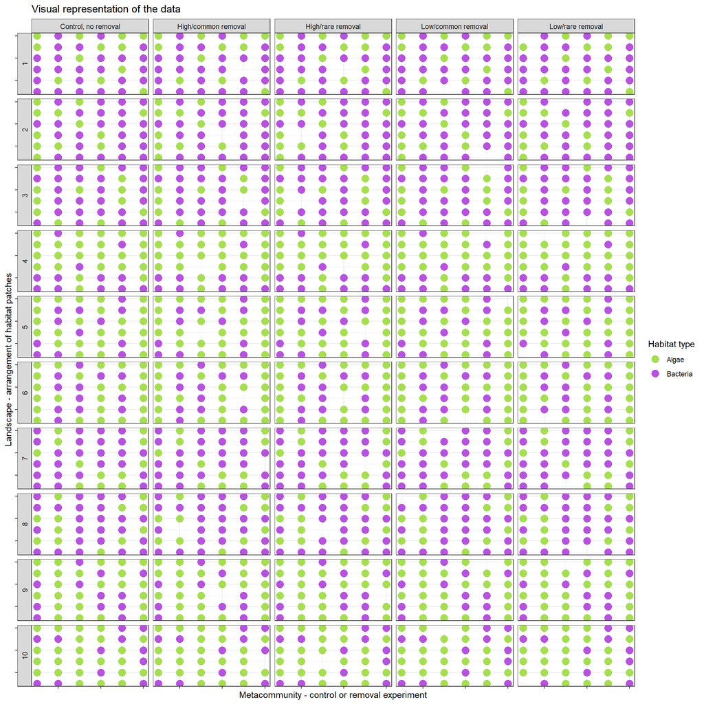

```r
resetarits_data %>%
  mutate(type = case_when(type == "A" ~ "Low/rare removal",
                          type == "B" ~ "Low/common removal",
                          type == "C" ~ "High/common removal",
                          type == "D" ~ "High/rare removal",
                          type == "E" ~ "Control, no removal"),
         habitat = ifelse(habitat == "C", "Algae", "Bacteria")) %>%
  ggplot(., aes(x = x.value, y = y.value, color = habitat)) +
  facet_grid(landscape~type, switch = "y")+
  geom_point(size = 4) +
  scale_color_manual(values = c("#a6de52", "#b652de"), ) +
  labs(title = "Visual representation of the data",
       x = "Metacommunity - control or removal experiment",
       y = "Landscape - arrangement of habitat patches") +
  guides(color = guide_legend(title = "Habitat type")) +
  theme_bw() +
  theme(axis.text = element_blank())
```

# Spatial structure

In the case of the control metacommunities, where no removals have happened, we have 36 patches connected through dispersal in a dendritic structure as shown in the figure below.

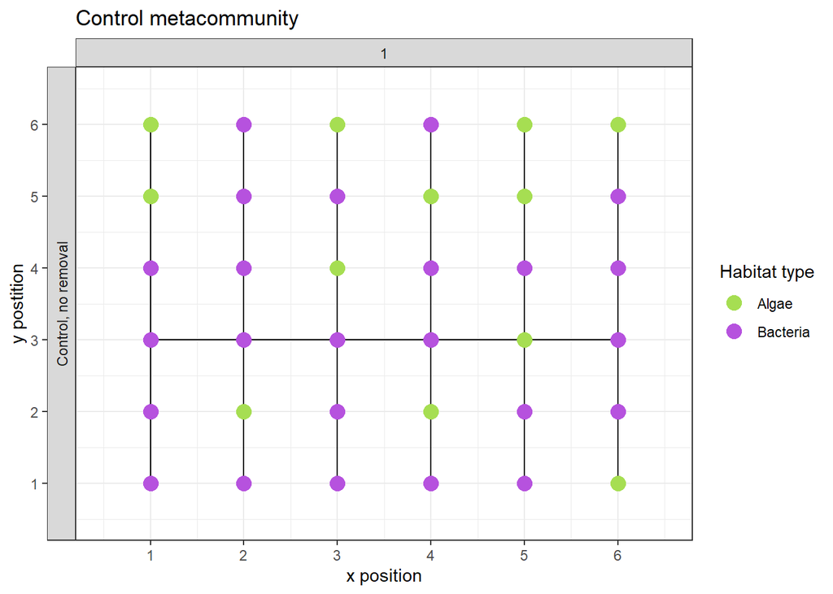

```r
control_metaco
```

The same applies for treatments in which a low connectivity patch is removed, and the dendritic network includes 35 patches. However, in treatments where a high connectivity patch was removed, the network is broken and we end up with several smaller segments of connected patches.

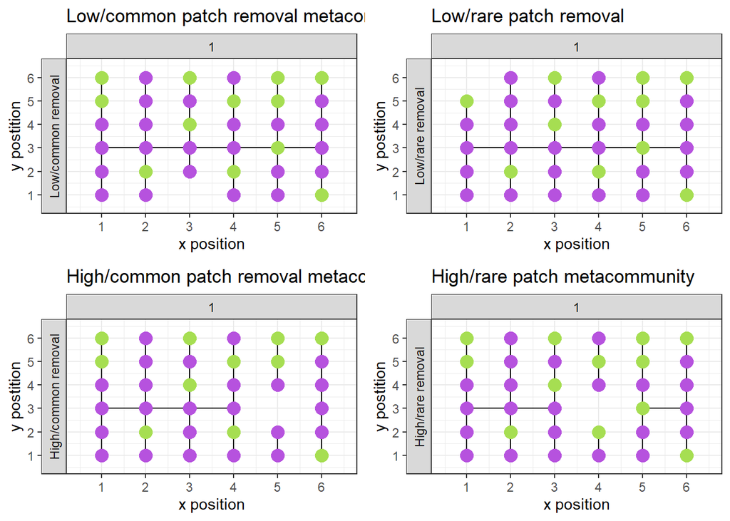

```r
plot_grid(lo.common, lo.rare,
          hi.common, hi.rare,
          ncol = 2, nrow = 2)
```

How can we use MEMs to describe this spatial structure, in particular the ones where we remove high connectivity patches and end up with multiple fragments of the metacommunity?

In the past, an artificial matrix of coordinates was created with a certain threshold to describe this dispersal structure for the control metacommunities by creating the spatial neighborhood with this threshold.

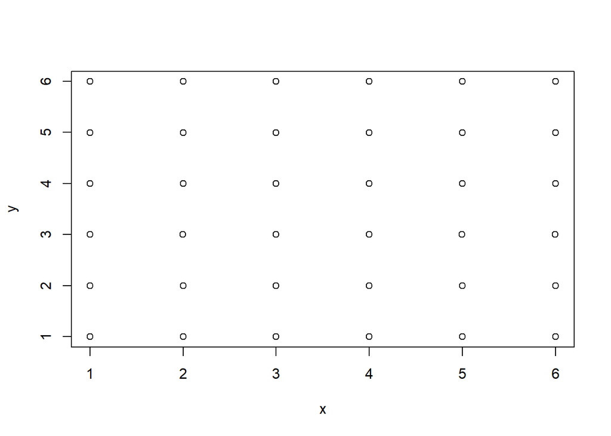

```r
x <- c(1,1,1,1,1,1,
       2,2,2,1.999,2,2,
       3,3,3,2.998,3,3,
       4,4,4,3.997,4,4,
       5,5,5,4.996,5,5,
       6,6,6,5.995,6,6)
y <- c(5.996,4.997,3.998,2.999,2,1.001,
       5.996,4.997,3.998,2.999,2,1.001,
       5.996,4.997,3.998,2.999,2,1.001,
       5.996,4.997,3.998,2.999,2,1.001,
       5.996,4.997,3.998,2.999,2,1.001,
       5.996,4.997,3.998,2.999,2,1.001)

coords <- coordinates(cbind(x,y))
plot(coords)
```

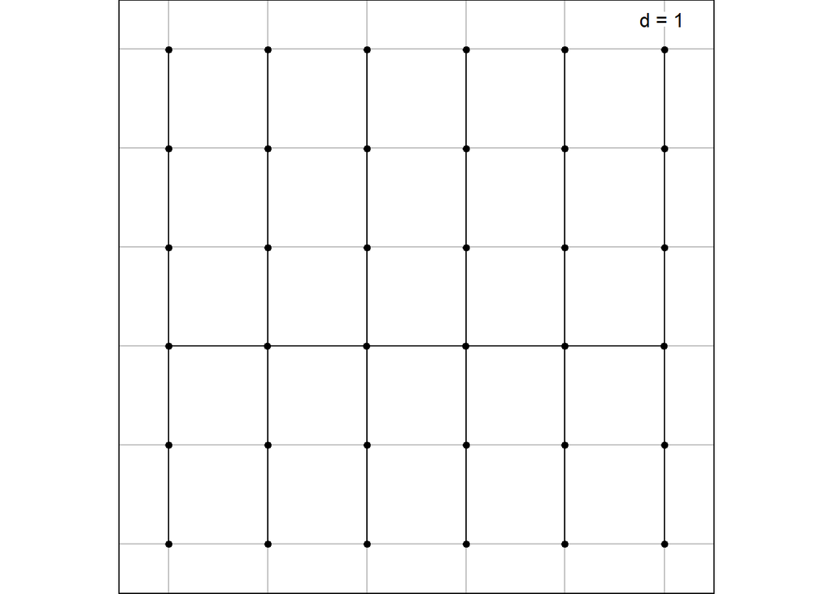

```r
# Build spatial neighborhood and using 0.9995 as the threshold
nb1 <- spdep::dnearneigh(coords, 0, 0.9995, longlat=F)
adegraphics::s.label(coords, nb = nb1)
```

```r
# Define spatial weighing matrices
neighb2.lw <- spdep::nb2listw(nb1, style="B")
# Now as a matrix of 1/0
weight.mat<-spdep::listw2mat(neighb2.lw)

# return Euclidean distances for the coordinates based on the spatial neighborhood
grid.thresh.d1 <- nbdists(nb1, coords)

# Spatial weights are defines as a function of distance
fdist <- lapply(grid.thresh.d1, function(x) 1-x/max(dist(coords)))

# This is the spatial weighting matrix
grid.invdist.lw <- nb2listw(nb1, glist = fdist, style="B")
print(listw2mat(grid.invdist.lw)[1:6,1:6], digits=2)
```

```
##   [,1] [,2] [,3] [,4] [,5] [,6]
## 1 0.00 0.86 0.00 0.00 0.00 0.00
## 2 0.86 0.00 0.86 0.00 0.00 0.00
## 3 0.00 0.86 0.00 0.86 0.00 0.00
## 4 0.00 0.00 0.86 0.00 0.86 0.00
## 5 0.00 0.00 0.00 0.86 0.00 0.86
## 6 0.00 0.00 0.00 0.00 0.86 0.00
```

```r
# Worried that we are taking these euclidean distances and coordinates and such, as real distances, but they are based on a sampling scheme, not actual distances?

# MEMs ----

# THIS is the function or step that is creating the MEM based on the distance matrices that come from the spdep::listw objects.
grid.invdist.MEM <- scores.listw(grid.invdist.lw, store.listw = TRUE)
# could also use mem()
grid.invdist.MEM <- mem(grid.invdist.lw, store.listw = TRUE)

grid.invdist.MEM
```

```
## Orthobasis with 36 rows and 35 columns
## Only 6 rows and 4 columns are shown
##         MEM1       MEM2      MEM3       MEM4
## 1 -0.2387288 -0.7461815 0.8922930 -0.9043830
## 2 -0.5558841 -1.1462262 1.5175011 -1.0552510
## 3 -1.0556559 -1.2257861 1.6884831 -0.4004407
## 4 -1.9022262 -0.9899625 1.3540596  0.8336447
## 5 -1.0016690 -0.9969382 1.2169422  0.1203581
## 6 -0.4301749 -0.6738563 0.7155638 -0.1937215
```

```r
summary(grid.invdist.MEM)
```

```
## Orthonormal basis: data.frame with 36 rows and 35 columns
## ----------------------------------------------------------------
## Columns form a centred orthonormal basis (i.e. 1n-orthogonal)
## for the inner product defined by the 'weights' attribute
## ----------------------------------------------------------------
##
## Attributes:
## - names: MEM1 ... MEM35
## - row.names: 1 ... 36
## - weights: 0.02777778 ... 0.02777778
## - values: 0.05553825 ... -0.06393086
## - class: orthobasisSp orthobasis data.frame
## - call: mem(listw = grid.invdist.lw, store.listw = TRUE)
```

```r
attr(grid.invdist.MEM, which = "value")
```

```
##  [1]  0.055538254  0.049232150  0.040563408  0.039456042  0.036971467
##  [6]  0.036677185  0.031112442  0.030300683  0.029164019  0.028204166
## [11]  0.027610062  0.024454350  0.015621665  0.012627898  0.008855665
## [16]  0.006378417  0.005179272 -0.005154441 -0.006373234 -0.008855254
## [21] -0.012502602 -0.015621203 -0.017272740 -0.027346021 -0.028181247
## [26] -0.029121764 -0.030291776 -0.031100627 -0.031535891 -0.036570027
## [31] -0.037975705 -0.040559325 -0.046403572 -0.055528512 -0.063930858
```

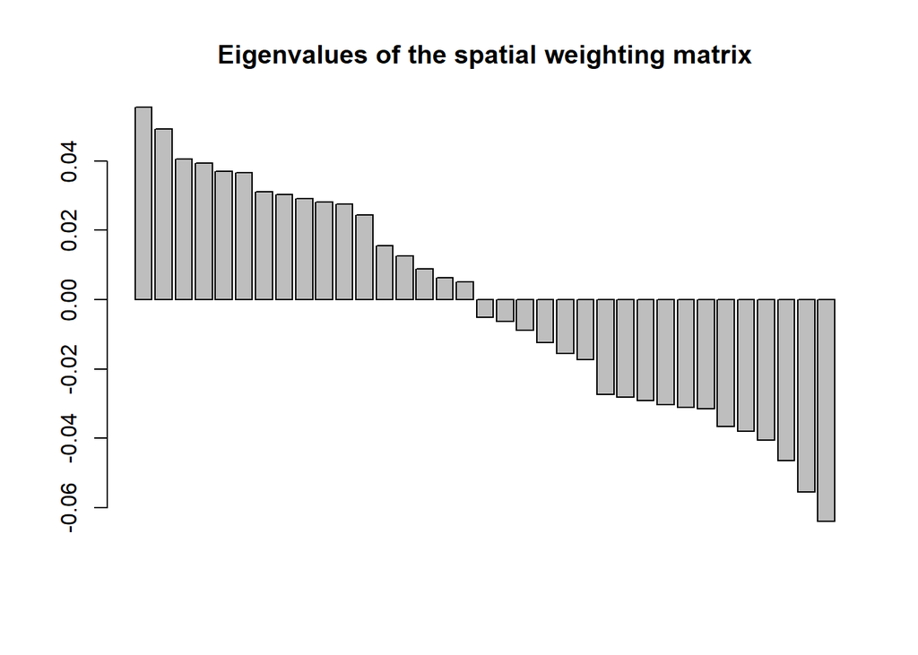

```r
barplot(attr(grid.invdist.MEM, which = "value"), main="Eigenvalues of the spatial weighting matrix")
```

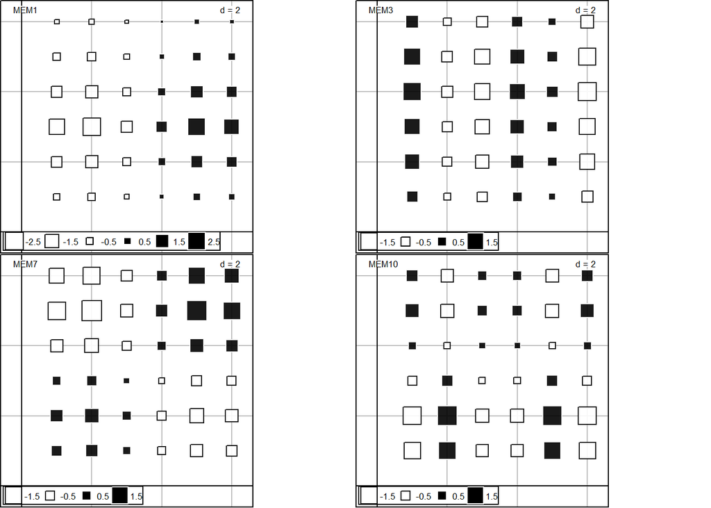

```r
s.value(coords, grid.invdist.MEM[, c(1,3,7,10)])
```

```r
# Compute moran's I
grid.MEM.Moran <- moran.randtest(grid.invdist.MEM, listw = grid.invdist.lw, nrepet = 999)
grid.MEM.Moran
```

```
## class: krandtest lightkrandtest
## Monte-Carlo tests
## Call: moran.randtest(x = grid.invdist.MEM, listw = grid.invdist.lw,
##     nrepet = 999)
##
## Number of tests:   35
##
## Adjustment method for multiple comparisons:   none
## Permutation number:   999
##     Test        Obs    Std.Obs   Alter Pvalue
## 1   MEM1  1.1975218  7.9635149 greater  0.001
## 2   MEM2  1.0615489  6.8907679 greater  0.001
## 3   MEM3  0.8746326  5.5140108 greater  0.001
## 4   MEM4  0.8507554  5.2407418 greater  0.001
## 5   MEM5  0.7971827  5.0598926 greater  0.001
```

[output cut: 30 more lines]

```r
head(attr(grid.invdist.MEM, "values") / grid.MEM.Moran$obs)
```

```
## MEM1.statistic MEM2.statistic MEM3.statistic MEM4.statistic MEM5.statistic
##     0.04637766     0.04637766     0.04637766     0.04637766     0.04637766
## MEM6.statistic
##     0.04637766
```

```r
# Which MEMs are significant?

which(grid.MEM.Moran$pvalue <= 0.05) # MEM with significant spatial correlation
```

```
##  [1]  1  2  3  4  5  6  7  8  9 10 11 12 13 14
```

```r
length(which(grid.MEM.Moran$pvalue <= 0.05))
```

```
## [1] 14
```

```r
# Now, we want to select those significant ones but only keep the eigenvectors that have positive eigenvalues.

# These are the significant MEMs
sig.MEM <- grid.invdist.MEM[, c(which(grid.MEM.Moran$pvalue <= 0.05))]

# Now, choose the ones with positive eigenvalues
attr(sig.MEM, which = "values") # Seems like they are all positive
```

```
##  [1] 0.05553825 0.04923215 0.04056341 0.03945604 0.03697147 0.03667718
##  [7] 0.03111244 0.03030068 0.02916402 0.02820417 0.02761006 0.02445435
## [13] 0.01562166 0.01262790
```

```r
grid.invdist.MEM.pos.sig <- sig.MEM

# Those are the significant MEMs for the control metacommunities
```